# Preparación del entrono

## Paquetes de conda

Instalar miniconda: https://docs.anaconda.com/free/miniconda/index.html

Crear un entorno y configurarlo

```
conda create -n zigbee python
conda activate zigbee
conda install pyserial jupyter
```

## Puertos serie de cada dispositvo

Gestión de dispositivos -> Com Ports

- COM5: dispositivo 1
- COM6: dispositivo 2
- COM8: dispositivo 3

## Importación de librerías

```python
import sys
import time
import serial
from math import exp # función exponencial
import matplotlib.pyplot as plt # graficar el resultado
```

## Funciones auxiliares

### Conversión de rssi (hexadecimal) a entero

```python
def rssi2dist(rssi):
    x = int(rssi.strip(),16)
    y = 0.0536*exp(0.1215*x)
    return y
["{0}=>{1:.3f}".format(hex,rssi2dist(hex)) for hex in ['1B', '34', '40', '47', '5E']]
```

```
['1B=>1.425', '34=>29.719', '40=>127.714', '47=>298.955', '5E=>4889.248']
```

### Extraer un substring después de una clave

```python
def extraer(respuesta, clave):
    pos1 = respuesta.find(clave)
    if pos1 > 0:
        pos1 += len(clave)
        pos2 = pos1 + respuesta[pos1:].find(" ")
        return int(respuesta[pos1:pos2])
    else:
        return -1

respuesta = "abcde baliza=3 posx=12 posy=34 abcde"
print(extraer(respuesta,"baliza="))
print(extraer(respuesta,"posx="))
print(extraer(respuesta,"posy="))
print(extraer("Baliza=1", "baliza="))
```

```
3
12
34
-1
```

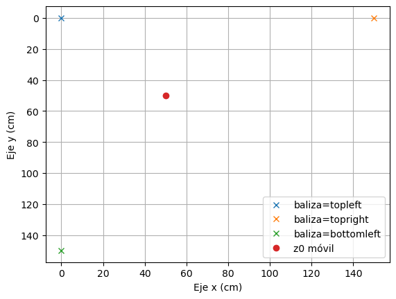

```python
def graficar_resultados(r1, r2, r3, movil):
    plt.plot(r1[1], r1[2], 'x', label='baliza='+str(r1[0]))
    plt.plot(r2[1], r2[2], 'x', label='baliza='+str(r2[0]))
    plt.plot(r3[1], r3[2], 'x', label='baliza='+str(r3[0]))
    x0, y0 = movil
    plt.plot(x0, y0, 'o', label='z0 móvil')
    plt.legend(loc='lower right')
    plt.xlabel("Eje x (cm)")
    plt.ylabel("Eje y (cm)")
    plt.gca().invert_yaxis()
    plt.grid()
    plt.show()
graficar_resultados(['topleft', 0, 0], ['topright', 150, 0], ['bottomleft', 0, 150], (50, 50))
```

## Clase Zigbee

Empaqueta toda la funcionalidad requerida para un dispositivo:

- Método init: Constructor de la clase.
  - Inicializa el puerto serie con parámetros por defecto (9600 8-N-1)
  - El argumento dev es de la forma '/dev/ttyUSB*' o 'COM*'
- Método command_mode_start: Entra en modo comando con +++
- Método command_mode_exit: Sale del modo comando con ATCN
- Método command_at: envía un mensaje tipo AT concatenando un fin de línea e imprime el comando y la respuesta
- Método configurar: configura un dispositivo y guarda la configuración de forma permanente
- Método enviar: envía un mensaje cambiando el destino con ATDL cuando sea preciso
- Metodo enviar_mi_posicion: envía un mensaje especial indicando el número y la posición de la baliza
- Método recibir_texto: recibe un texto cualquiera enviado por otro dispositivo
- Método recibir_baliza: recibe el texto especial envido por una baliza y añade la distancia
- Método posicionar: calcula la posición aproximada a partir de los mensajes de 3 balizas

```python
class Zigbee:
    puerto = None
    panid = None
    myid = None
    dlid = None
    posx = None
    posy = None

    def __init__(self, myid, device, posx=None, posy=None):
        self.myid = str(myid)
        self.puerto = serial.Serial(device, 9600,
                            parity=serial.PARITY_NONE,
                            bytesize=serial.EIGHTBITS,
                            stopbits=serial.STOPBITS_ONE,
                            rtscts=False)
        self.posx = posx
        self.posy = posy

    def command_mode_start(self):
        time.sleep(1)   # guarda de 1 segundo
        self.puerto.write(b'+++')
        time.sleep(1)   # ademas hay que esperar 1 segundo al OK
        print("{}>+++ ".format(self.myid, self.puerto.read(3).decode('utf-8')))
        return

    def command_mode_exit(self):
        self.command_at('ATCN')
        return

    def command_at(self, msg):
        time.sleep(1)
        toSerial = msg+"\r\n" # concatenar LF, CR
        self.puerto.write(toSerial.encode('ascii', 'replace'))
        self.puerto.flush()
        time.sleep(.2)
        bytesToRead = self.puerto.inWaiting() # imprimir respuesta
        fromSerial = self.puerto.read(bytesToRead)
        print ("z{}>{}: [{}]".format(self.myid, msg, fromSerial.decode('utf-8').strip()))
        return fromSerial.decode('utf-8')

    def configurar(self, panid='3210'):
        self.panid = str(panid)             # guardar el valor de panid como string
        self.command_mode_start()           # entrar en modo comando con +++
        self.command_at('AT')               # comprobar que se aceptan comandos AT
        self.command_at('ATRE')             # resetea la configuración guardada
        self.command_at('ATID '+self.panid) # definir el PANID
        self.command_at('ATDH 0')           # definir direcciones de 16 bits
        self.command_at('ATMY '+self.myid)  # definir la dirección MY addres
        self.command_at('ATWR')             # guardar la configuración de forma permanente
        # self.command_at('ATCH')
        self.command_mode_exit()            # salir del modo +++

    def enviar(self, destino='2', msg='mensaje'):
        print("z{} envía a z{}: [{}]".format(self.myid, destino, msg))
        if self.dlid != str(destino):
            self.dlid = str(destino)
            self.command_mode_start()           # entrar en modo comando con +++
            self.command_at('ATDL '+self.dlid)  # establecer el destino del mensaje
            self.command_mode_exit()            # salir del modo +++
        self.puerto.write(msg.encode('ascii', 'replace'))
        self.puerto.flush()
        time.sleep(.1)

    def enviar_mi_posicion(self, destino):
        msg = " baliza={} posx={} posy={} ".format(self.myid, self.posx, self.posy)
        self.enviar(destino, msg)

    def recibir_texto(self):
        # time.sleep(.1)                     # espero a que llegue un mensaje completo
        tamano = self.puerto.inWaiting()     # espero al puerto serie
        resp = self.puerto.read(tamano)      # leo del puerto serie
        resp = resp.decode('utf-8')          # convierto de ascii a unicode
        print("z{} recibe: [{}]".format(self.myid, resp))
        return (resp)

    def recibir_baliza(self):
        tamano = self.puerto.inWaiting()     # espero al puerto serie
        resp = self.puerto.read(tamano)      # leo del puerto serie
        resp = resp.decode('utf-8')          # convierto de ascii a unicode

        #resp = resp.strip()                  # quito blancos y fines de línea al inicio y final
        #lista = resp.split(" ")              # creo una lista separando la respuesta por espacios

        #baliza = lista[1]                    # la baliza es el segundo elemento de la lista
        #posx = int(lista[3])                 # la posición x de la baliza es el cuarto elemento
        #posy = int(lista[5])                 # la posición y de la balia es el sexto elemento
        baliza = extraer(resp, "baliza=")
        posx = extraer(resp, "posx=")
        posy = extraer(resp, "posy=")

        self.command_mode_start()            # entrar en modo comando con +++
        rssi = self.command_at('ATDB')       # obtener el RSSI
        dist = rssi2dist(rssi)               # convertir el valor de rssi a cm
        self.command_mode_exit()             # salir del modo +++

        print("z{} recibe: baliza={} x={} y={} RSSI=[{}] => Distancia={:.2f} (cm)".format(
            self.myid, baliza, posx, posy, rssi.strip(), dist))
        return (baliza, posx, posy, dist)

    def posicionar(self, resp1, resp2, resp3):
        b1, x1, y1, d1 = resp1 # self.recibir_baliza()
        b2, x2, y2, d2 = resp2 #self.recibir_baliza()
        b3, x3, y3, d3 = resp3 # self.recibir_baliza()
        if b1>0 and b2>0 and b3>0:
            xmin = max(x1-d1, x2-d2, x3-d3)
            xmax = min(x1+d1, x2+d2, x3+d3)
            ymin = max(y1-d1, y2-d2, y3-d3)
            ymax = min(y1+d1, y2+d2, y3+d3)
            x = (xmin+xmax)/2
            y = (ymin+ymax)/2
            print("La posición de {} es x={:.3f}, y={:.3f}".format(self.myid, x,y))
            return (x, y)
        else:
            print("Alguna de las respuesas no indica la baliza")
            return None

    def cerrar(self):
        self.puerto.close()
```

## Creación de objetos Zigbee para cada uno de los cuatro dispositivos

### Objeto Zigbee para instanciar el nodo móvil

```python
z0 = Zigbee(0, "COM9")
```

### Objetos Zigbee para instanciar las balizas fijas

```python
z1 = Zigbee(1, "COM5", 240, 55)
z2 = Zigbee(2, "COM6", 90, 60)
z3 = Zigbee(3, "COM8", 20, 170)
```

## Configurar las balizas y el portátil móvil

La configuración sólo es necesaria la primera vez, ya que se guarda en memoria con ATWR

### Configurar el nodo móvil

```python
z0.configurar()
```

```
0>+++
z0>AT: [OK]
z0>ATRE: [OK]
z0>ATID 3210: [OK]
z0>ATDH 0: [OK]
z0>ATMY 0: [OK]
z0>ATWR: [OK]
z0>ATCN: [OK]
```

### Configurar las balizas

```python
z1.configurar()
z2.configurar()
z3.configurar()
```

```
1>+++
z1>AT: [OK]
z1>ATRE: [OK]
z1>ATID 3210: [OK]
z1>ATDH 0: [OK]
z1>ATMY 1: [OK]
z1>ATWR: [OK]
z1>ATCN: [OK]
2>+++
z2>AT: [OK]
z2>ATRE: [OK]
z2>ATID 3210: [OK]
z2>ATDH 0: [OK]
z2>ATMY 2: [OK]
z2>ATWR: [OK]
z2>ATCN: [OK]
3>+++
z3>AT: [OK]
z3>ATRE: [OK]
z3>ATID 3210: [OK]
z3>ATDH 0: [OK]
z3>ATMY 3: [OK]
z3>ATWR: [OK]
z3>ATCN: [OK]
```

## Pruebas unitarias de las balizas

### Envío de mensajes de texto

```python
balizas = [z1, z2, z3]
for b in balizas:
    print("Soy la baliza {} en ({}, {})".format(b.myid, b.posx, b.posy))
```

```
Soy la baliza 1 en (240, 55)
Soy la baliza 2 en (90, 60)
Soy la baliza 3 en (20, 170)
```

```python
z1.enviar(2, "Mensaje de 1 a 2")
resp = z2.recibir_texto()
```

```
z1 envía a z2: [Mensaje de 1 a 2]
1>+++
z1>ATDL 2: [OK]
z1>ATCN: [OK]
z2 recibe: [
Mensaje de 1 a 2]
```

```python
z1.enviar(2, "Otro de 1 a 2, no hace falta DL al ser el mismo destino")
resp2 = z2.recibir_texto()
```

```
z1 envía a z2: [Otro de 1 a 2, no hace falta DL al ser el mismo destino]
z2 recibe: [Otro de 1 a 2, no ]
```

```python
z1.enviar(3, "Mensaje de 1 a 3, hace falta DL al ser distinto destino")
resp3 = z3.recibir_texto()
```

```
z1 envía a z3: [Mensaje de 1 a 3, hace falta DL al ser distinto destino]
1>+++
z1>ATDL 3: [OK]
z1>ATCN: [OK]
z3 recibe: [
Mensaje de 1 a 3, hace fa]
```

### Pruebas con mensajes de balizas

```python
for b in balizas:
    b.enviar_mi_posicion(0)
    resp = z0.recibir_baliza()
    print("Baliza={}, Posx={}, Posy={}, Dist={}".format(resp[0], resp[1], resp[2], resp[3]))
```

```
z1 envía a z0: [ baliza=1 posx=240 posy=55 ]
1>+++
z1>ATDL 0: [OK]
z1>ATCN: [OK]
0>+++
z0>ATDB: [2D]
z0>ATCN: [OK]
z0 recibe: baliza=1 x=240 y=55 RSSI=[2D] => Distancia=12.70 (cm)
Baliza=1, Posx=240, Posy=55, Dist=12.696086407626055
z2 envía a z0: [ baliza=2 posx=90 posy=60 ]
2>+++
OK]ATDL 0: [e falta DL al ser el mismo destinoOK
z2>ATCN: [OK]
0>+++
z0>ATDB: [3B]
z0>ATCN: [OK]
z0 recibe: baliza=2 x=90 y=60 RSSI=[3B] => Distancia=69.57 (cm)
Baliza=2, Posx=90, Posy=60, Dist=69.56724154568433
z3 envía a z0: [ baliza=3 posx=20 posy=170 ]
3>+++
OK]ATDL 0: [DL al ser distinto destinoOK
z3>ATCN: [OK]
0>+++
z0>ATDB: [3B]
z0>ATCN: [OK]
z0 recibe: baliza=3 x=20 y=170 RSSI=[3B] => Distancia=69.57 (cm)
Baliza=3, Posx=20, Posy=170, Dist=69.56724154568433
```

## Prueba completa desde posición inicial cercana a las balizas

```python
z1.enviar_mi_posicion(0)
r1 = z0.recibir_baliza()

z2.enviar_mi_posicion(0)
r2 = z0.recibir_baliza()

z3.enviar_mi_posicion(0)
r3 = z0.recibir_baliza()

x0, y0 = z0.posicionar(r1, r2, r3)
```

```
z1 envía a z0: [ baliza=1 posx=240 posy=55 ]
0>+++
z0>ATDB: [2D]
z0>ATCN: [OK]
z0 recibe: baliza=1 x=240 y=55 RSSI=[2D] => Distancia=12.70 (cm)
z2 envía a z0: [ baliza=2 posx=90 posy=60 ]
0>+++
z0>ATDB: [3A]
z0>ATCN: [OK]
z0 recibe: baliza=2 x=90 y=60 RSSI=[3A] => Distancia=61.61 (cm)
z3 envía a z0: [ baliza=3 posx=20 posy=170 ]
0>+++
z0>ATDB: [3B]
z0>ATCN: [OK]
z0 recibe: baliza=3 x=20 y=170 RSSI=[3B] => Distancia=69.57 (cm)
La posición de 0 es x=158.436, y=84.064
```

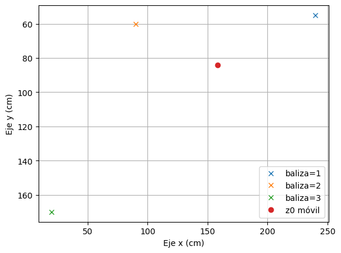

```python
graficar_resultados(r1, r2, r3, (x0, y0))
```

## Repetición de la prueba alejando el dispositivo de las balizas

```
z1 envía a z0: [ baliza=1 posx=240 posy=55 ]
1>+++
z1>ATDL 0: [OK]
z1>ATCN: [OK]
0>+++
z0>ATDB: [3E]
z0>ATCN: [OK]
z0 recibe: baliza=1 x=240 y=55 RSSI=[3E] => Distancia=100.16 (cm)
z2 envía a z0: [ baliza=2 posx=90 posy=60 ]
2>+++
z2>ATDL 0: [OK]
z2>ATCN: [OK]
0>+++
z0>ATDB: [41]
z0>ATCN: [OK]
z0 recibe: baliza=2 x=90 y=60 RSSI=[41] => Distancia=144.21 (cm)
z3 envía a z0: [ baliza=3 posx=20 posy=170 ]
3>+++
z3>ATDL 0: [OK]
z3>ATCN: [OK]
0>+++
z0>ATDB: [3A]
z0>ATCN: [OK]
z0 recibe: baliza=3 x=20 y=170 RSSI=[3A] => Distancia=61.61 (cm)
La posición de 0 es x=110.723, y=131.777
```

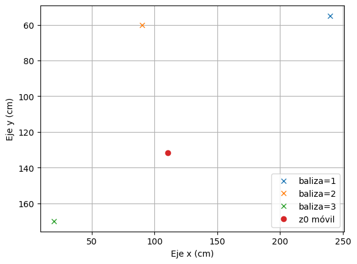

```python
z1.enviar_mi_posicion(0)
r1 = z0.recibir_baliza()

z2.enviar_mi_posicion(0)
r2 = z0.recibir_baliza()

z3.enviar_mi_posicion(0)
r3 = z0.recibir_baliza()

x0, y0 = z0.posicionar(r1, r2, r3)
graficar_resultados(r1, r2, r3, (x0, y0))
```

## Cerrar los puertos serie

```python
z0.cerrar()
```

```python
z1.cerrar()
z2.cerrar()
z3.cerrar()
```